# Elements of Data Science: A First Course

# COMS W4995 008 2017 3

## Week 10: Clustering and Topic Modeling

## Today:

- ML Overview
- Review: PCA
- Clustering
  - k-Means
  - Hierarchical Agglomerative Clustering (HAC)
- Topic Modeling: Latent Dirichlet Allocation (LDA)
- ? Recommendation Engines

# Overview: General Types of ML

### Supervised Learning: $\{(x,y)\}_L$

- Classification: $y \in \{0,1,\ldots\}$
- Regression: $y \in \mathbb{R}$
- Semi-Supervised Learning: $\{(x,y)\}_L + \{x\}_U$
- Reinforcement Learning: States, Actions and Rewards

### Unsupervised Learning: $\{x\}_U$

- **Dimensionality Reduction** (eg. PCA)
- **Clustering**
- Anomaly/Novelty Detection

# Review: Dimensionality Reduction with PCA

```python
# a dataset of transformed face and non-face data
df_faces = pd.read_csv('../data/face_nonface_data.zip')

# last column is label
X = df_faces.iloc[:,:-1].values
y = df_faces.iloc[:,-1].values
```

### How linearly separable are the two classes?

```python
# to plot the next few examples
def plot_example(X,y,title,xlabel,ylabel,legend=['not face','face']):
    fig = plt.figure(figsize=(8,8));
    for i in range(2):
        X_subset = X[y==i]
        plt.scatter(X_subset[:,0],X_subset[:,1],s=100,alpha=.8);
    plt.legend(legend);
    plt.title(title);
    plt.xlabel(xlabel);
    plt.ylabel(ylabel);
```

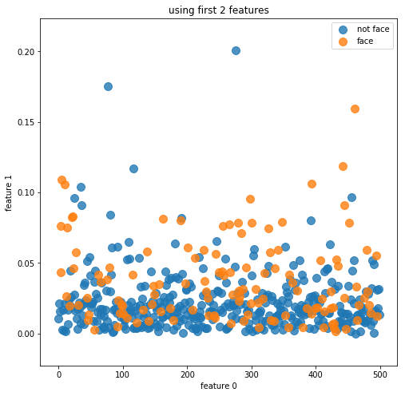

```python
# what if we just plot the first 2 dimensions?

plot_example(X,y,'using first 2 features','feature 0','feature 1')
```

```python
# what if we selected 2 dimensions using f_classif (linear dependency between x and y)?

from sklearn.feature_selection import SelectKBest, f_classif

skb = SelectKBest(f_classif,k=2)
X_2D = skb.fit_transform(X,y)
support = np.where(skb.get_support())[0] # get the features that we've selected
```

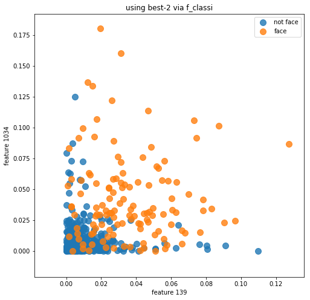

```python
# plot each class separately
plot_example(X_2D,y,'using best-2 via f_classi','feature '+str(support[0]),'feature '+str(support[1]))
```

```python
# what about PCA?

from sklearn.decomposition import PCA

# create a PCA model which will return the first 2 components
pca = PCA(n_components=2)

# transform the dataset
X_pca = pca.fit_transform(X)
```

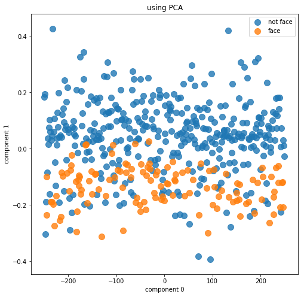

```python
# plot each class separately
plot_example(X_pca,y,'using PCA','component 0','component 1')
```

# Clustering

- Group $X$ into $k$ clusters
- Many ways to do it: **k-Means**, **HAC**, Spectral, ...
- importantly: there is no *correct* cluster labeling (there is no target)!

## Why do clustering?

- exploratory data analysis
- group media: images, music, news articles, ...
- social networks: group users, ...
- marketing: consumer populations, ...
- science: gene families, psychological groups, ...
- image segmentation: group pixels or regions
- ...

## One Method: k-Means

- not to be confused with k-NN!
- have to specify the number of clusters k
- have to specify a distance metric
- an iterative method

#### How it works

FIRST: choose initial k means

A: fix means -> assign all points to thier closest mean

B: fix assignments -> recalculate means

RETURN TO A: Repeat till convergence!

### Example in 2d: clustering loans

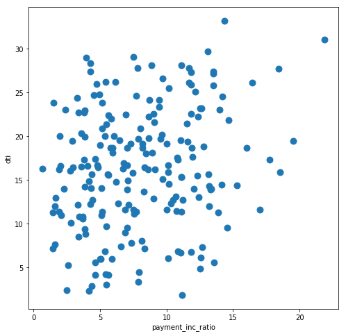

```python
# loading and plotting the data
X = pd.read_csv('../data/loan200.csv')[['payment_inc_ratio','dti']].values
fig = plt.figure(figsize=(8,8))
plt.scatter(X[:,0],X[:,1],s=80);plt.xlabel('payment_inc_ratio');plt.ylabel('dti');
```

### KMeans in sklearn

```python
from sklearn.cluster import KMeans
```

```python
km = KMeans(n_clusters=4) # initilize to find 4 clusters
```

```python
c = km.fit_predict(X)     # fit and return cluster assignments
```

```python
c[:10]
```

```
array([0, 2, 1, 1, 1, 1, 2, 3, 0, 0], dtype=int32)
```

```python
# function to plot clusters
def plot_clusters(X,c):
    fig = plt.figure(figsize=(9,9))
    for i in range(np.max(c) + 1):
        cluster = X[c == i]
        _ = plt.scatter(cluster[:,0],cluster[:,1],s=80,label=i,cmap='Set2')
        _ = plt.legend()
    plt.xlabel('payment_inc_ratio');plt.ylabel('dti');
```

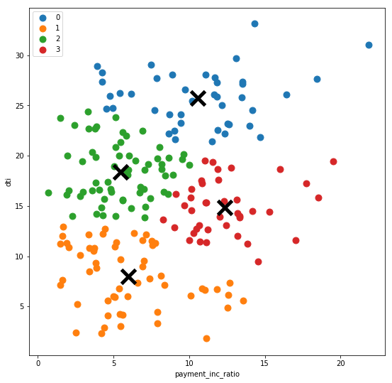

```python
plot_clusters(X,c)            # plot clusters

for m in km.cluster_centers_: # plot cluster centers
    plt.gca().plot(m[0],m[1], marker='x',c='k', ms=20, mew=5)
```

### How good are the clusters?

#### Within Cluster Sum of Squares

\begin{equation} \Large \sum_{k=1}^K \sum_{x_i \in C_k} {\mid\mid x_i - \mu_k \mid\mid_2}^2 \end{equation}

- If this is high, items in cluster are far from their means.
- If this is low, items in cluster are close to their means.

where $\mid\mid x - \mu \mid\mid_2 = \sqrt{\sum_{j=1}^d (x_j - \mu_j)^2}$

[figure not shown]

from https://dashee87.github.io/data%20science/general/Clustering-with-Scikit-with-GIFs/

### Things you need to define for K-Means

- number of clusters k
- initial locations of means

### Choosing K

- one way: using elbow in the sum of squared errors

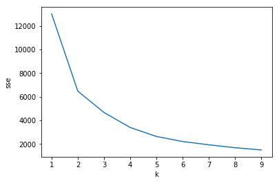

```python
sse = []
for i in range(1,10):
    sse.append(KMeans(n_clusters=i).fit(X).inertia_)

_ = plt.plot(range(1,10),sse); _ = plt.xlabel('k'); _ = plt.ylabel('sse')
```

## Another Method: Hierarchical Agglomerative Clustering

- very simple
- don't have to specify the number of clusters up front
- generates binary tree over the dataset

### Example in 2D

- Initially, every point is its own cluster
- Find the pair that are closest
- Merge them into a single cluster
- Repeat, until the entire dataset is one big cluster

[figure not shown]

from https://dashee87.github.io/data%20science/general/Clustering-with-Scikit-with-GIFs/

### Important: How to measure closeness between two clusters?

Have to choose a

- **distance metric**
- **linkage criteria**.

## Distance metrics

- Euclidean : $\sqrt{\sum_{i=1}^n \left(x_i - \mu\right)^2}$
- Manhattan : $\sum_{i=1}^n \mid x_i - \mu \mid$
- Cosine : $ 1 - \frac{\sum{x_i\mu}}{\mid\mid x_i \mid\mid_2 \mid\mid \mu \mid\mid_2}$
- ... : https://numerics.mathdotnet.com/distance.html

## Linkage

- **single**: *shortest distance* from member of one cluster to member of the other
- **average**: *average distance* of members of one cluster to members of the other
- **complete**: *greatest distance* from member of one cluster to member of the other
- **ward**: minimize sum of squared differences between all clusters (only euclidean metric)

## Result is a dendrogram

```python
# nice helper function for creating a dendrogram
from scipy.cluster import hierarchy
```

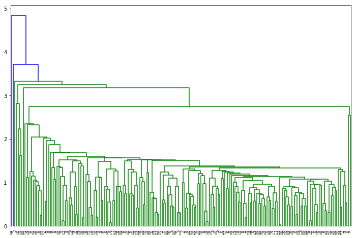

```python
Z = hierarchy.linkage(X,'single')

fig = plt.figure(figsize=(12,8))
_ = hierarchy.dendrogram(Z)
```

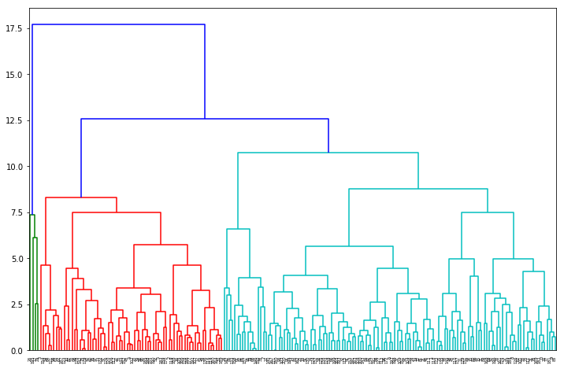

```python
Z = hierarchy.linkage(X,'average')

fig = plt.figure(figsize=(12,8))
_ = hierarchy.dendrogram(Z)
```

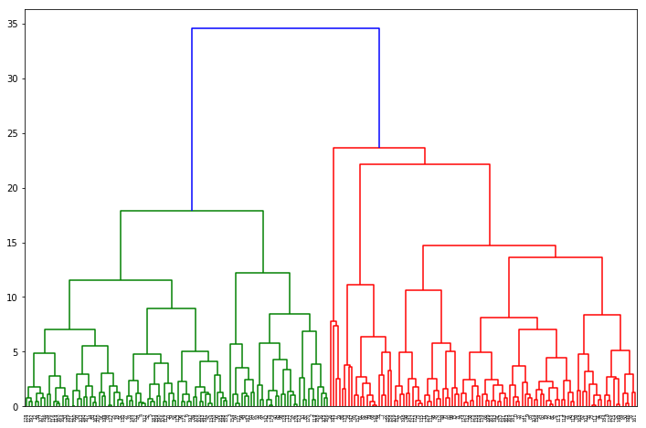

```python
Z = hierarchy.linkage(X,'complete')

fig = plt.figure(figsize=(12,8))
_ = hierarchy.dendrogram(Z)
```

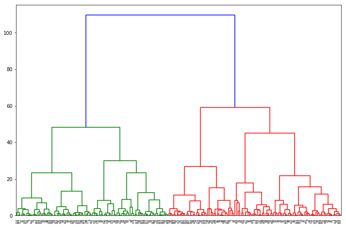

```python
Z = hierarchy.linkage(X,'ward')

fig = plt.figure(figsize=(12,8))
_ = hierarchy.dendrogram(Z)
```

### HAG Using sklearn

```python
from sklearn.cluster import AgglomerativeClustering
```

```python
# unfortunately, single doesn't show up till a later version of sklearn
hac = AgglomerativeClustering(linkage='average', n_clusters=4)
```

```python
c = hac.fit_predict(X)
```

```python
c[:10]
```

```
array([0, 0, 2, 2, 2, 2, 0, 3, 0, 0])
```

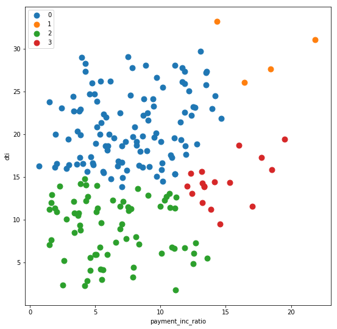

```python
plot_clusters(X,c) # 4 clusters, average linkage
```

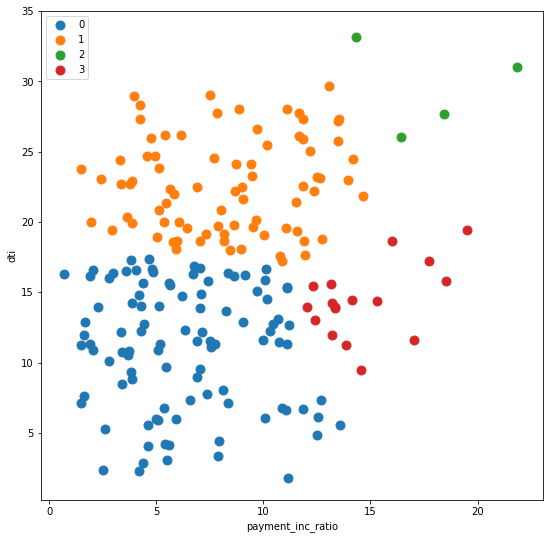

```python
c = AgglomerativeClustering(n_clusters=4, linkage='complete').fit_predict(X)
plot_clusters(X,c) # 4 clusters, complete linkage
```

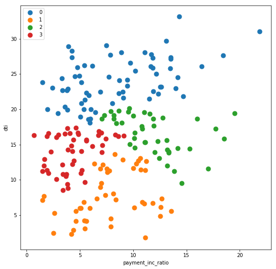

```python
c = AgglomerativeClustering(n_clusters=4, linkage='ward').fit_predict(X)
plot_clusters(X,c) # 4 clusters, ward linkage
```

## Many other cluster algorithms

[figure not shown]

from https://scikit-learn.org/stable/modules/clustering.html

## How to evaluate?

- use external data: are there any labels? how pure are the clusters?
- many others, see sklearn documentation

# Latent Dirichlet Allocation: See Slides

# Recommendation Engines

- Spotify
- Netflix
- Amazon
- ....

Objective: produced a ranked list of items

### Types of recommender systems

- Content-Based
- Collaborative Filtering
- Knowledge-Based (uses domain knowledge)
- Hybrid and Ensemble

### Content-Based

- If I like product A, and product B is like product A, I'll probably like product B
- Use similarity of items to recommend items
- Matrix: Items x Items
- Values: Similarity of Items

#### Issues with content-based

- need to discover the important features
- these may vary between users and change over time

### Collaborative Filtering

- If both you and I like MovieA, and you like MovieB, I'll probably like movie A
- Use similarity of user preferences to recommend items
- Matrix: Users x Items
- Values: Rankings

#### Issues with Collaborative

- the cold start problem
- sparcity

### Evaluation

- **Precision@N** : Out of top N, how many were true
- **Recall@N** : Out of all true, how many were in top N

for more see: Recommender Systems by Charu C. Aggarwal